[OHI Science](http://ohi-science.org) | [Citation policy](http://ohi-science.org/citation-policy/)

# OHI 2023 - Sea ice habitat (coastal protection goal and habitat subgoal)

Compiled on Tue Sep 5 10:46:23 2023 by arobinson

[REFERENCE RMD FILE:](https://cdn.rawgit.com/OHI-Science/ohiprep/master/globalprep/hab_seaice/v2021/hab_seaice_dataprep.html)

# 1 Summary

This data prep markdown calls a series of scripts to download and analyze sea ice data for the habitat subgoal and coastal protection goal. See [data layers documentation](http://ohi-science.org/ohi-global/layers#hab_seaice_extent) for more information.

# 2 Updates from previous assessment

[Version 1](https://doi.org/10.5067/8GQ8LZQVL0VL) of the data set which had been used previously was retired. The version 2 data available was in netcdf format, while the data was previously stored in .bin files. The workflow was updated to accommodate the new file type and file naming system.

# 3 Data Source

**Reference:**

DiGirolamo, N., C. L. Parkinson, D. J. Cavalieri, P. Gloersen, and H. J. Zwally. (2022). Sea Ice Concentrations from Nimbus-7 SMMR and DMSP SSM/I-SSMIS Passive Microwave Data, Version 2 [Data Set]. Boulder, Colorado USA. NASA National Snow and Ice Data Center Distributed Active Archive Center. https://doi.org/10.5067/MPYG15WAA4WX. Date Accessed 06-05-2023.

**Downloaded**: June 5th 2023

**Description**: Monthly sea ice extent data.

Data can be downloaded here: https://nsidc.org/data/nsidc-0051. The user guide for the data is located [`here`](https://nsidc.org/sites/default/files/documents/user-guide/nsidc-0051-v002-userguide.pdf).

## 3.1 Downloading the raw data

There are several options for downloading the raw data files. If the user is familiar with python see option 1. If not, see option 2. Option 3 is not fully developed but it may be worth investing time in changing to this workflow.

**Option 1 - Python**

1. To download the raw data, go to this website: https://nsidc.org/data/nsidc-0051 and make an account.
2. After making an account, scroll down from the link above and navigate to the data access tool. Type _??????_v into the search bar. This is because all monthly files follow the format “NSIDC0051_SEAICE_PS_H25km_YYYYMMDD_v2.0.nc”, with H replaced with hemisphere (N or S).
3. Click the download script option just below the search results. It is important that you first input the search option as this will be placed into the python script automatically to filter the results to what we want.
4. Place this file (eg. `nsidc-download_NSIDC-0051.001_2022-06-06.py`) in the folder `/home/shares/ohi/git-annex/globalprep/_raw_data/NSIDC_SeaIce/<version_year>`
5. Create “xml”, “north” , “south” and “tmp” folders in the same directory above
- Open a terminal on Mazu in your R session and run:
  - `cd /home/shares/ohi/git-annex/globalprep/_raw_data/NSIDC_SeaIce/<version_year>`
  - `mkdir north`
  - `mkdir south`
  - `mkdir xml`
  - `mkdir tmp`
6. Run the python script
- In your terminal on Mazu run:
  - `python nsidc-download_NSIDC-0051.001_<download_date>.py`
  - Notes:
    - You will be prompted to enter your username and password
    - This may take quite a while to run
    - If you experience server disconnection issues, download the data using option 2
7. next we move the files to the folders we created
- You should ensure you are still in `/home/shares/ohi/git-annex/globalprep/_raw_data/NSIDC_SeaIce/<version_year>` and then run:
  - `mv ./*.xml ./xml`
  - `mv ./**PS_N*.nc ./north`
  - `mv ./**PS_S*.nc ./south`
8. Your files should be in the correct place and you may proceed to the methods section of this workflow

**Option 2 - Order Files**

To download the raw data, you must go to this website: https://nsidc.org/data/nsidc-0051, and navigate to the data access tool. Type _??????_v into the search bar.

This is because all monthly files follow the format “NSIDC0051_SEAICE_PS_H25km_YYYYMMDD_v2.0.nc”, with H replaced with hemisphere (N or S). Click “Order Files” and wait until your order is processed. Once processed (should only take a couple of minutes, you will receive an email with instructions), download the zip file and place it into the git-annex/globalprep/_raw_data/NSIDC_SeaIce/<vyear> folder on Mazu and extract it.

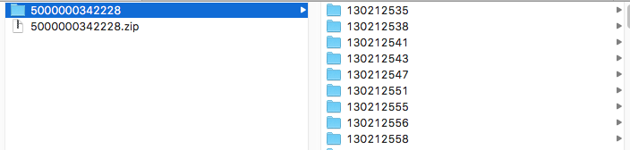

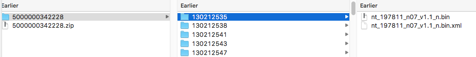

We need to create “xml”, north” and “south” folders and place the .nc and .xml files within them.

To do this, we will be working in the terminal (alternatively, you could do it manually, but it takes much longer, see v2020 script).

Open the terminal within R Studion on Mazu. Now we need to cd into the correct folder on mazu, which where we have placed our seaice raw data: - Enter `cd /home/shares/ohi/git-annex/globalprep/_raw_data/NSIDC_SeaIce/<vyear>/<folder_number>` to do this.

Now move all of the xml files to the xml folder that your have created:

- `mv **/*.xml`

And do the same with the North files and South files:

- `mv **/*PS_N*.nc ./north`
- `mv **/*PS_S*.nc ./south`

NOTE: remember to change the assessment year to whatever assessment you are conducting.

The final folder structure looks like this, where you have created new “north”, “south”, and “xml” folders:

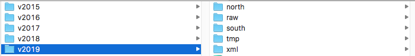

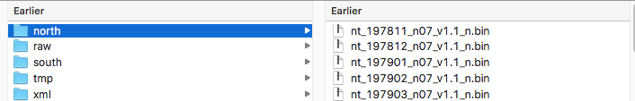

**Option 3 - Download through R (new and incomplete)**

This option is not complete and will need some work but amy be the best option moving forward. See [the NOAA tutorial](https://coastwatch.pfeg.noaa.gov/projects/r/Projected.html#download-the-sea-ice-concentration-data) for downloading directly with R through the PolarWatch ERDDAP server.

This will download the data as NETCDF (`.nc`) files. This is the same file format that is currently used in version 2 of the data set.

See [issue 206](https://github.com/OHI-Science/globalfellows-issues/issues/206#issuecomment-1147696785) for example code to get started.

**For complete documentation and more information about data access, please see:**

http://nsidc.org/data/nsidc-0051.html

If you wish to be notified of updates or corrections to these data, please register with NSIDC User Services by sending e-mail to: `nsidc@nsidc.org`

Identify yourself as a user of “Sea Ice Concentrations from Nimbus-7 SMMR and DMSP SSM/I-SSMIS Passive Microwave Data (NSIDC-0051).” Include your name, e-mail address, postal address, and telephone number.

If you have questions, please contact NSIDC User Services.

CONTACT INFORMATION: User Services National Snow and Ice Data Center CIRES, 449 UCB University of Colorado Boulder, CO USA 80309-0449 Phone: +1 303-492-6199 Fax: +1 303-492-2468 E-mail: nsidc@nsidc.org

**Time range**: 1979-2022

# 4 Methods

## 4.1 Setup

Load all relevant libraries, establish/define parameters and commonly used pathnames. Manually change scenario and data years in file pathnames code chunk to reflect the most recent data (d) and current assessment year (v) in setup code chunk.

```r
## Install R packages where necessary
pkg <- c("raster", "fasterize", "sf", "sp", "rgdal", "fields", "here", "tictoc", "dplyr", "ggplot2") # "fields" for colors in Status_Trend.R
new.pkg <- pkg[!(pkg %in% installed.packages())]
if (length(new.pkg)){install.packages(new.pkg)}
if (!("ohicore" %in% installed.packages())){devtools::install_github("ohi-science/ohicore")}

## Load libraries, set directories
lapply(c(pkg, "ohicore"), require, character.only = TRUE)

## UPDATE THESE!
current_year <- 2023
last_year <- 2022 # final year of data (all months)

assess_year <- paste0("v", current_year) # assessment year for file paths
previous_year <- paste0("v", last_year)  # previous assessment year
```

```r
source("../../../workflow/R/common.R") # directory locations
```

```
## This file makes it easier to process data for the OHI global assessment
##  by creating the following objects:
##
##  * dir_M = identifies correct file path to Mazu (internal server) based on your operating system
##  * mollCRS = the crs code for the mollweide coordinate reference system we use in the global assessment
##  * regions_shape() = function to load global shapefile for land/eez/high seas/antarctica regions
##  * ohi_rasters() = function to load two rasters: global eez regions and ocean region
##  * region_data() = function to load 2 dataframes describing global regions
##  * rgn_syns() = function to load dataframe of region synonyms (used to convert country names to OHI regions)
##  * low_pop() = function to load dataframe of regions with low and no human population
##  * UNgeorgn = function to load dataframe of UN geopolitical designations used to gapfill missing data
```

## 4.2 Location of Maps

These maps of the OHI regions were made by the PreparingSpatialFiles.R script. If there are changes to the OHI regions, the `PreparingSpatialFiles.R` script will need to be run. Additionally, it is critical to walk through the `ObtainingData.R` script if any of the spatial files have been modified (this saves the files as spatial points).

The original polygon files are used from: git-annex/globalprep/_raw_data/NSIDC_SeaIce/v2015. However, we use the `fasterize` package to rasterize the polygons and save them to: git-annex/globalprep/_raw_data/NSIDC_SeaIce/v2023.

```r
maps <- file.path(dir_M, "git-annex/globalprep/_raw_data/NSIDC_SeaIce", assess_year)
```

## 4.3 Establish Parameters

- epsg projection 3411 - nsidc sea ice polar stereographic north (http://spatialreference.org/ref/epsg/3411/)
- epsg projection 3412 - nsidc sea ice polar stereographic south (http://spatialreference.org/ref/epsg/3412/)

```r
pixel = 25000 # pixel dimension in meters for both x and y
prj.n = "+proj=stere +lat_0=90 +lat_ts=70 +lon_0=-45 +k=1 +x_0=0 +y_0=0 +a=6378273 +b=6356889.449 +units=m +no_defs"
prj.s = "+proj=stere +lat_0=-90 +lat_ts=-70 +lon_0=0 +k=1 +x_0=0 +y_0=0 +a=6378273 +b=6356889.449 +units=m +no_defs"
prj.mol = "+proj=moll +lon_0=0 +x_0=0 +y_0=0 +ellps=WGS84 +datum=WGS84 +units=m +no_defs"

## Filepath (fp), filepath for the final monthly data in north and south folders
fp.n <- file.path(dir_M, "git-annex/globalprep/_raw_data/NSIDC_SeaIce", assess_year, "north")
fp.s <- file.path(dir_M, "git-annex/globalprep/_raw_data/NSIDC_SeaIce", assess_year, "south")

poles = c("n","s")
years = c(1979:last_year) # full range of data
months = 1:12
n.pym = length(poles)*length(years)*length(months)
i.pym = 0
```

## 4.4 Function 1

Collects the data for each month/year from mazu and add to raster stack that is saved in tmp folder as: `n_rasters_points.rdata` or `s_rasters_points.rdata`. And, if it doesn’t already exist, it converts the region shapefile into a raster points file. See `ObtainingData.R` script for more details.

```r
tic()
## Previously (<2022) update to some file paths with the correct assessment year in ObtainingData.R was needed
## Currently (2023) this is automatic from this script with `assess_year` variable
source("ObtainingData.R")
toc()
## should take ~30 minutes to completely run
```

## 4.5 Function 2

Using the data from the .rdata files created from Function 1 with the `ObtainingData.R` script, this function calculates status and trend for shoreline ice and ice edge habitat. Data is saved in intermediate (`int`) folder:

- Habitat: `n_IceEdgeHabitat.csv`, `s_IceEdgeHabitat.csv`
- Coastal Protection: `n_IceShoreProtection.csv`, `s_IceShoreProtection.csv`

```r
tic()
ref.years <- 1979:2000
source("Status_Trend.R") # calculates status and trend for shoreline ice and ice edge habitat
toc()
```

## 4.6 Final calculations and organization

Read in ice edge habitat and ice shore protection csv-format datasets, remove anamolous eez regions with minimal ice cover, remove disputed regions. Bind these datasets and convert to units of km^2. Save seaice health, extent, trend, and extent data.

```r
n_edge <- read.csv("int/n_IceEdgeHabitat_ref1979to2000.csv")
s_edge <- read.csv("int/s_IceEdgeHabitat_ref1979to2000.csv")
edge <- rbind(n_edge, s_edge)
edge  <- edge %>%
  dplyr::filter(Reference_avg1979to2000monthlypixels != 0) %>%
  dplyr::filter(!(rgn_id %in% c(59, 141, 219, 4, 172, 94))) %>%  # anomalous eez regions with very little ice cover
  dplyr::filter(!(rgn_id %in% c("248300","258510","258520","258600","258700"))) %>% # cut due to minimal ice (<200km2/yr - avg of months)
  dplyr::filter(rgn_nam != "DISPUTED") %>%
  dplyr::mutate(habitat="seaice_edge")

n_shore <- read.csv("int/n_IceShoreProtection_ref1979to2000.csv")
s_shore <- read.csv("int/s_IceShoreProtection_ref1979to2000.csv")
shore <- rbind(n_shore, s_shore)
shore <- shore %>%
  dplyr::filter(Reference_avg1979to2000monthlypixels != 0) %>%
  dplyr::filter(!(rgn_id %in% c(59, 89, 177, 178))) %>%  # anomalous eez regions with very little ice cover
  dplyr::filter(rgn_nam != "DISPUTED") %>%
  dplyr::mutate(habitat = "seaice_shoreline")

data <- rbind(edge, shore)
data  <- data %>%
  dplyr::mutate(km2 = Reference_avg1979to2000monthlypixels/12 * (pixel/1000)^2)

write.csv(data, "int/sea_ice.csv", row.names = FALSE)

## Health data
health <- data %>%
  dplyr::filter(rgn_typ == "eez") %>%
  dplyr::select(rgn_id, habitat, dplyr::starts_with("pctdevR")) %>%
  tidyr::gather("year", "health", -(1:2)) %>%
  dplyr::mutate(year = substring(year, 9, 12)) %>%
  dplyr::mutate(year = as.numeric(year)) %>%
  dplyr::mutate(health = ifelse(health > 1, 1, health))

write.csv(health, "output/hab_ice_health_eez.csv", row.names = FALSE) # save sea ice health data

## Trend data
trend <- data %>%
  dplyr::filter(rgn_typ == "eez") %>%
  dplyr::select(rgn_id, habitat, dplyr::starts_with("Trend")) %>%
  tidyr::gather("year", "trend", -(1:2)) %>%
  dplyr::mutate(year = substring(year, 13, 16)) %>%
  dplyr::mutate(year = as.numeric(year)) %>%
  dplyr::mutate(trend = trend * 5) %>%
  dplyr::mutate(trend = ifelse(trend > 1, 1, trend)) %>%
  dplyr::mutate(trend = ifelse(trend < (-1), -1, trend))

write.csv(trend, "output/hab_ice_trend_eez.csv", row.names = FALSE) # save sea ice trend data

## Sea ice extent data
extent <- data %>%
   dplyr::filter(rgn_typ == "eez") %>%
   dplyr::mutate(year = 2016) %>% # extent not updated each year (historic extent of the sea ice habitat); updated last 2016 bc of source methods
  dplyr::select(rgn_id, habitat, year, km2)

write.csv(extent, "output/hab_ice_extent_eez.csv", row.names = FALSE) # save sea ice extent data
```

## 4.7 Data Checks

1. Compare to last year’s data. There should be a strong correlation between these data.
2. Pair with region names for sanity check.

```r
## Health comparison

#compare same years with different version year
health <- read.csv("output/hab_ice_health_eez.csv")
ice_health_eez <- read.csv(sprintf("../%s/output/hab_ice_health_eez.csv", previous_year)) %>% # compare to last year's data
  dplyr::rename(health_prev_assess = health) %>%
  dplyr::left_join(health, by = c("rgn_id", "habitat", "year")) %>%
  na.omit("health")

comp_plot <-ggplot() + geom_point(data = ice_health_eez, aes(x = health_prev_assess, y = health)) + labs(x = "previous health (2012-2021)", y = "health (2012-2021)") + geom_abline(slope = 1, intercept = 0, col = "red")
ggplotly(comp_plot)


### let's compare the data year 2022 to data year 2021 (current data year vs the year before)

## Pair with region names
regions <- rgn_master %>%
  dplyr::select(rgn_id = rgn_id_2013, rgn_name = rgn_nam_2013) %>%
  unique()


health_2022 <- health %>%
  dplyr::filter(year == current_year-1)

health_2021 <- ice_health_eez %>%
  dplyr::filter(year == last_year-1) %>%
  dplyr::select(-year, -health)

health_old_new <-  dplyr::left_join(health_2022, health_2021) %>% mutate(difference = (health - health_prev_assess)) %>% left_join(regions)


year_change_plot <-ggplot() +
  geom_point(data = health_old_new,
             aes(x = health_prev_assess,
                 y = health, text = paste("Region ID:", rgn_id, "<br>Habitat:", habitat))) + labs(x = "previous assessment health", y = "current health") + geom_abline(slope = 1, intercept = 0, col = "red")

ggplotly(year_change_plot, tooltip = "text")
## Trend comparison
trend <- read.csv("output/hab_ice_trend_eez.csv")
ice_trend_eez <- read.csv(sprintf("../%s/output/hab_ice_trend_eez.csv", previous_year)) %>% # compare to last year's data
  dplyr::rename(trend_prev_assess = trend) %>%
  dplyr::left_join(trend, by = c("rgn_id", "habitat", "year")) %>%
  na.omit("trend")

#update label years
trend_comp <- ggplot() + geom_point(data = ice_trend_eez, aes(x = trend_prev_assess, y = trend)) + labs(x = "previous assessment trend (2016-2021)", y= "current assessment trend (2016-2021)") + geom_abline(slope = 1, intercept = 0, col = "red")

ggplotly(trend_comp)

### let's compare the data year 2022 to data year 2021 (current data year vs the year before)

trend_2022 <- trend %>%
  dplyr::filter(year == (current_year - 1))

trend_2021 <- ice_trend_eez %>%
  dplyr::filter(year == last_year -1) %>%
  dplyr::select(-year, -trend)

trend_old_new <- dplyr::left_join(trend_2022, trend_2021) %>% mutate(difference = (trend - trend_prev_assess)) %>% left_join(regions)

year_trend_change_plot <-ggplot() + geom_point(data = trend_old_new, aes(x = trend_prev_assess, y = trend, text = paste("Region ID:", rgn_id, "<br>Habitat:", habitat))) + labs(x = "previous year trend", y = "current trend") + geom_abline(slope = 1, intercept = 0, col = "red")

ggplotly(year_trend_change_plot, tooltip = "text")

## Extent comparison
extent <- read.csv("output/hab_ice_extent_eez.csv", stringsAsFactors = FALSE)
ice_extent_eez <- read.csv(sprintf("../%s/output/hab_ice_extent_eez.csv", previous_year), stringsAsFactors = FALSE) %>% # compare to last year's data
  dplyr::rename(km2_prev_assess = km2) %>% left_join(extent)

ggplot(data = ice_extent_eez) +geom_point(aes(x =km2_prev_assess, y = km2)) + geom_abline(slope = 1, intercept = 0, col = "red")


### let's compare the data year 2022 to data year 2021

extent_2022 <- extent

extent_2021 <- ice_extent_eez

extent_old_new <- dplyr::left_join(extent_2022, extent_2021)

 # extent doesn't change at all, because we use the same year for extent every year
ggplot(data = extent_old_new) + geom_point(aes(x = km2_prev_assess, y = km2)) + geom_abline(slope = 1, intercept = 0, col = "red")


## Pair with region names
regions <- rgn_master %>%
  dplyr::select(rgn_id = rgn_id_2013, rgn_name = rgn_nam_2013) %>%
  unique()

## Make sure sea ice health across regions makes intuitive sense...
data <- read.csv("output/hab_ice_health_eez.csv") %>%
  dplyr::left_join(regions, by = "rgn_id") %>%
  dplyr::arrange(habitat, health)



#### Check largest score changes for v2021 ####



## Bouvet Island, rgn_id == 105, HAB score +15.15


# health
bouv_health <- health_old_new %>%
  dplyr::filter(rgn_id == 105) %>%
  dplyr::mutate(diff = health - health_prev_assess) # +0.19

# trend
bouv_trend <- trend_old_new %>%
  dplyr::filter(rgn_id == 105) %>%
  dplyr::mutate(diff = trend - trend_prev_assess) # trend got worse

## checked against previous conditions, and it looks like Bouvet Island and Jan Mayen (our two largest increases for 2021) have pretty volatile condition scores year after year, so I think this is ok. Nothing went wrong in the data processing on our part.
```

[output not shown]

## 4.8 Gapfill

There was no gapfilling for these data. Created gapfill files with values of 0. Note: all layers need a gf file, eventhough if there was no gapfilling. In this case the gapfill value is 0 for every region.

```r
## Health gapfill
hab_ice_health_gf <- read.csv("output/hab_ice_health_eez.csv")%>%
  dplyr::mutate(gapfilled = 0) %>%
  dplyr::select(rgn_id, year, gapfilled)

write.csv(hab_ice_health_gf, "output/hab_ice_health_eez_gf.csv", row.names=FALSE) # save sea ice health gapfill file

## Extent gapfill
hab_ice_extent_gf <- read.csv("output/hab_ice_extent_eez.csv")%>%
  dplyr::mutate(gapfilled = 0) %>%
  dplyr::select(rgn_id, year, gapfilled)

write.csv(hab_ice_health_gf, "output/hab_ice_extent_eez_gf.csv", row.names=FALSE) # save sea ice extent gapfill file

## Trend gapfill
hab_ice_trend_gf <- read.csv("output/hab_ice_trend_eez.csv")%>%
  dplyr::mutate(gapfilled = 0) %>%
  dplyr::select(rgn_id, year, gapfilled)

write.csv(hab_ice_health_gf, "output/hab_ice_trend_eez_gf.csv", row.names=FALSE) # save sea ice trend gapfill file
```